# Water Quality Analysis in North England, 2023–2025

- Show All Code
- Hide All Code
- View Source

DSC8001 Data Handling Project

Author

Wisdom Owogoga Ogbeche

Published

October 30, 2026

# 1 Business Understanding

## 1.1 Project Background and Objectives

Water-quality monitoring produces measurements that can help identify patterns in the condition of water bodies. This project uses three datasets provided for the DSC8001 Data Handling Project, covering 2023, 2024 and 2025, to explore variations in recorded water-quality measurements.

### 1.1.1 Research question

**Did river water quality in North England improve or decline between 2023 and 2025, and which catchments and pollutants drive the change?**

### 1.1.2 Objectives

The project aims to:

1. Assess the structure, coverage and quality of the datasets.
2. Compare key river water-quality indicators across 2023, 2024 and 2025.
3. Compare water quality patterns across the selected catchments and assess how they changed between 2023 and 2025.
4. Communicate findings, limitations and potential implications through clear tables, visualisations and a reproducible report.

## 1.2 Situation Assessment

The project will use R for data analysis, `dplyr` for data manipulation, `ggplot2` for visualisation, Quarto for reporting and Git for version control. The main constraints are the assignment deadline, data quality and the availability of comparable measurements across the three years.

## 1.3 Stakeholders

Stakeholders include environmental monitoring agencies, water resource managers, policymakers and researchers interested in water quality. The findings may help them understand patterns in the available records and identify areas for further investigation.

## 1.4 Goals and Success Criteria

The goal is to identify meaningful patterns in selected water-quality measurements between 2023 and 2025.

Success would be evaluated based on;

- The analysis will compare water quality indicators across 2023, 2024 and 2025, identify statistically significant changes, and report effect sizes to measure the magnitude of these changes.
- The report will identify changes in water quality across the Northumberland & Tyne and Wear & Tees catchments, using clearly labelled tables and figures to present the findings and discussing limitations that may affect their interpretation.

## 1.5 Preliminary Project Plan

The analysis followed the CRISP-DM methodology, which provides a structured approach to data understanding, data preparation, analysis, evaluation and reporting (Chapman et al., 2000)

The datasets will first be examined for structure, coverage and quality. Suitable observations will then be prepared for exploratory analysis using descriptive statistics, tables and visualisations. The results will be evaluated against the research question before the findings are communicated through a rendered Quarto HTML report. The plan will be refined as the analysis progresses.

# 2 Data Understanding

## 2.1 Data Collection

The project uses three water-quality datasets provided for the DSC8001 Data Handling Project, covering 2023, 2024 and 2025. The files are stored in the project’s `Data` directory.

The datasets are `WaterQuality23.csv`, `WaterQuality24.csv` and `WaterQuality25.csv`. They contain information about sampling locations, sampling dates, measured determinands, recorded results and measurement units.

```r
# Import the three datasets and store in variables
water23 <- read_csv("Data/WaterQuality23.csv", show_col_types = FALSE)
water24 <- read_csv("Data/WaterQuality24.csv", show_col_types = FALSE)
water25 <- read_csv("Data/WaterQuality25.csv", show_col_types = FALSE)
```

## 2.2 Initial Data Description

Initial data inspection was conducted to examine the structure of each dataset, identify the available variables and their data types, and determine the number of observations and variables recorded in each year.

### 2.2.1 2023 Dataset

```r
# Inspect sample records to understand the 2023 dataset's contents
head(water23)
```

```
# A tibble: 6 × 17
  id        samplingPoint.notation samplingPoint.prefLa…¹ samplingPoint.longit…²
  <chr>     <chr>                  <chr>                                   <dbl>
1 https://… NE-400A0044            1/22/5/50 LOUGH HOUSE…                  -1.74
2 https://… NE-400A0048            WHITTLE, COAL AUTHORI…                  -1.71
3 https://… NE-400A0048            WHITTLE, COAL AUTHORI…                  -1.71
4 https://… NE-400A0048            WHITTLE, COAL AUTHORI…                  -1.71
5 https://… NE-400A0048            WHITTLE, COAL AUTHORI…                  -1.71
6 https://… NE-400A0048            WHITTLE, COAL AUTHORI…                  -1.71
# ℹ abbreviated names: ¹samplingPoint.prefLabel, ²samplingPoint.longitude
# ℹ 13 more variables: samplingPoint.latitude <dbl>,
#   samplingPoint.region <chr>, samplingPoint.area <chr>,
#   samplingPoint.subArea <chr>, samplingPoint.samplingPointStatus <chr>,
#   samplingPoint.samplingPointType <chr>, phenomenonTime <dttm>,
#   samplingPurpose <chr>, sampleMaterialType <chr>,
#   determinand.notation <chr>, determinand.prefLabel <chr>, result <chr>, …
```

```r
# Check the number of rows and columns in the 2023 dataset
dim(water23)
```

```
[1] 130389     17
```

```r
# Check variable types of the 2023 dataset to identify potential data preparation needs
tibble(
  Column = names(water23),
  Data_Type = map_chr(water23, ~ class(.x)[1])
)
```

```
# A tibble: 17 × 2
   Column                            Data_Type
   <chr>                             <chr>
 1 id                                character
 2 samplingPoint.notation            character
 3 samplingPoint.prefLabel           character
 4 samplingPoint.longitude           numeric
 5 samplingPoint.latitude            numeric
 6 samplingPoint.region              character
 7 samplingPoint.area                character
 8 samplingPoint.subArea             character
 9 samplingPoint.samplingPointStatus character
10 samplingPoint.samplingPointType   character
11 phenomenonTime                    POSIXct
12 samplingPurpose                   character
13 sampleMaterialType                character
14 determinand.notation              character
15 determinand.prefLabel             character
16 result                            character
17 unit                              character
```

### 2.2.2 2024 Dataset

```r
# Inspect sample records to understand the 2024 dataset's contents
head(water24)
```

```
# A tibble: 6 × 17
  id        samplingPoint.notation samplingPoint.prefLa…¹ samplingPoint.longit…²
  <chr>     <chr>                  <chr>                                   <dbl>
1 https://… NE-400B0158            1/22/05/26 ABBEY WELL…                  -1.67
2 https://… NE-400B0158            1/22/05/26 ABBEY WELL…                  -1.67
3 https://… NE-400B0158            1/22/05/26 ABBEY WELL…                  -1.67
4 https://… NE-400B0164            HIGH PARK WALL FARM, …                  -1.95
5 https://… NE-400B0164            HIGH PARK WALL FARM, …                  -1.95
6 https://… NE-400B0164            HIGH PARK WALL FARM, …                  -1.95
# ℹ abbreviated names: ¹samplingPoint.prefLabel, ²samplingPoint.longitude
# ℹ 13 more variables: samplingPoint.latitude <dbl>,
#   samplingPoint.region <chr>, samplingPoint.area <chr>,
#   samplingPoint.subArea <chr>, samplingPoint.samplingPointStatus <chr>,
#   samplingPoint.samplingPointType <chr>, phenomenonTime <dttm>,
#   samplingPurpose <chr>, sampleMaterialType <chr>,
#   determinand.notation <chr>, determinand.prefLabel <chr>, result <chr>, …
```

```r
# Display the number of rows and columns in the 2024 dataset
dim(water24)
```

```
[1] 117977     17
```

```r
# Check variable types of the 2024 dataset to identify potential data preparation needs
tibble(
  Column = names(water24),
  Data_Type = map_chr(water24, ~ class(.x)[1])
)
```

```
# A tibble: 17 × 2
   Column                            Data_Type
   <chr>                             <chr>
 1 id                                character
 2 samplingPoint.notation            character
 3 samplingPoint.prefLabel           character
 4 samplingPoint.longitude           numeric
 5 samplingPoint.latitude            numeric
 6 samplingPoint.region              character
 7 samplingPoint.area                character
 8 samplingPoint.subArea             character
 9 samplingPoint.samplingPointStatus character
10 samplingPoint.samplingPointType   character
11 phenomenonTime                    POSIXct
12 samplingPurpose                   character
13 sampleMaterialType                character
14 determinand.notation              character
15 determinand.prefLabel             character
16 result                            character
17 unit                              character
```

### 2.2.3 2025 Dataset

```r
# Inspect sample records to understand the 2025 dataset's contents
head(water25)
```

```
# A tibble: 6 × 17
  id        samplingPoint.notation samplingPoint.prefLa…¹ samplingPoint.longit…²
  <chr>     <chr>                  <chr>                                   <dbl>
1 https://… NE-400A0048            WHITTLE, COAL AUTHORI…                  -1.71
2 https://… NE-400A0048            WHITTLE, COAL AUTHORI…                  -1.71
3 https://… NE-400A0048            WHITTLE, COAL AUTHORI…                  -1.71
4 https://… NE-400A0048            WHITTLE, COAL AUTHORI…                  -1.71
5 https://… NE-400A0048            WHITTLE, COAL AUTHORI…                  -1.71
6 https://… NE-400A0048            WHITTLE, COAL AUTHORI…                  -1.71
# ℹ abbreviated names: ¹samplingPoint.prefLabel, ²samplingPoint.longitude
# ℹ 13 more variables: samplingPoint.latitude <dbl>,
#   samplingPoint.region <chr>, samplingPoint.area <chr>,
#   samplingPoint.subArea <chr>, samplingPoint.samplingPointStatus <chr>,
#   samplingPoint.samplingPointType <chr>, phenomenonTime <dttm>,
#   samplingPurpose <chr>, sampleMaterialType <chr>,
#   determinand.notation <chr>, determinand.prefLabel <chr>, result <chr>, …
```

```r
# Display the number of rows and columns in the 2025 dataset
dim(water25)
```

```
[1] 141906     17
```

```r
# Check variable types of the 2025 dataset to identify potential data preparation needs
tibble(
  Column = names(water25),
  Data_Type = map_chr(water25, ~ class(.x)[1])
)
```

```
# A tibble: 17 × 2
   Column                            Data_Type
   <chr>                             <chr>
 1 id                                character
 2 samplingPoint.notation            character
 3 samplingPoint.prefLabel           character
 4 samplingPoint.longitude           numeric
 5 samplingPoint.latitude            numeric
 6 samplingPoint.region              character
 7 samplingPoint.area                character
 8 samplingPoint.subArea             character
 9 samplingPoint.samplingPointStatus character
10 samplingPoint.samplingPointType   character
11 phenomenonTime                    POSIXct
12 samplingPurpose                   character
13 sampleMaterialType                character
14 determinand.notation              character
15 determinand.prefLabel             character
16 result                            character
17 unit                              character
```

### 2.2.4 Comparison of Dataset Dimensions

```r
# Compare the size of the three annual datasets before combining
# them. This helps us understand how much data is available for
# each year and identify differences in the number of records
# or variables that may affect the subsequent analysis
dataset_summary <- tibble(
  # Label each dataset with its corresponding sampling year
  Year = c(2023, 2024, 2025),

  #Count the rows to compare the number of observations
  # available in each year's dataset
  Rows = c(
    nrow(water23),
    nrow(water24),
    nrow(water25)
  ),

  # Count the columns to check whether the datasets contain
  # the same number of variables before they are combined
  Columns = c(
    ncol(water23),
    ncol(water24),
    ncol(water25)
  )
)

# Display the comparison to inspect the datasets before
# proceeding with data preparation and analysis
dataset_summary
```

```
# A tibble: 3 × 3
   Year   Rows Columns
  <dbl>  <int>   <int>
1  2023 130389      17
2  2024 117977      17
3  2025 141906      17
```

### 2.2.5 Merge the Datasets

The three datasets have matching column structures, allowing them to be combined into a single dataset. A year identifier is added to each record to preserve its origin and support comparisons over time.

```r
# Combine the three annual datasets into one dataset so that
# water quality measurements can be analysed consistently
# across the 2023–2025 study period
water_all <- bind_rows(
  "2023" = water23,
  "2024" = water24,
  "2025" = water25,
  .id = "year"
) |>

  # Convert the year to an integer so it can be used consistently
  # when grouping observations and comparing water quality
  # measurements across the three years
  mutate(year = as.integer(year))

# Inspect the combined dataset's structure, including its
# variables and data types, to check that it is ready for
# subsequent cleaning and analysis
glimpse(water_all)
```

```
Rows: 390,272
Columns: 18
$ year                              <int> 2023, 2023, 2023, 2023, 2023, 2023, …
$ id                                <chr> "https://environment.data.gov.uk/wat…
$ samplingPoint.notation            <chr> "NE-400A0044", "NE-400A0048", "NE-40…
$ samplingPoint.prefLabel           <chr> "1/22/5/50 LOUGH HOUSE - ESPLEY MORP…
$ samplingPoint.longitude           <dbl> -1.7384, -1.7097, -1.7097, -1.7097, …
$ samplingPoint.latitude            <dbl> 55.1993, 55.3451, 55.3451, 55.3451, …
$ samplingPoint.region              <chr> "NorthEast", "NorthEast", "NorthEast…
$ samplingPoint.area                <chr> "NORTH EAST - NORTHUMBERLAND DURHAM …
$ samplingPoint.subArea             <chr> "GROUNDWATER - NORTH EAST AREA", "GR…
$ samplingPoint.samplingPointStatus <chr> "OPEN", "OPEN", "OPEN", "OPEN", "OPE…
$ samplingPoint.samplingPointType   <chr> "GROUNDWATER - BOREHOLE", "GROUNDWAT…
$ phenomenonTime                    <dttm> 2023-10-05 11:04:00, 2023-11-07 09:…
$ samplingPurpose                   <chr> "ENVIRONMENTAL MONITORING STATUTORY …
$ sampleMaterialType                <chr> "GROUNDWATER", "GROUNDWATER", "GROUN…
$ determinand.notation              <chr> "7668", "0052", "0061", "0076", "007…
$ determinand.prefLabel             <chr> "No flow /No sample", "Lead, Dissolv…
$ result                            <chr> "No flow/discharge at sampling point…
$ unit                              <chr> "Coded Result", "MICROGRAM PER LITRE…
```

The dimensions of the combined dataset are 390272 rows and 18 columns.

## 2.3 Data Exploration

### 2.3.1 Sampling Locations and Coverage

Figure 1 compares the number of observations recorded for each sample material type between 2023 and 2025. To keep the chart readable, only material types with more than 3,000 observations across the three years were included. This threshold was used to focus on frequently recorded sample types; less common types were excluded from the figure but retained in the dataset for other analyses.

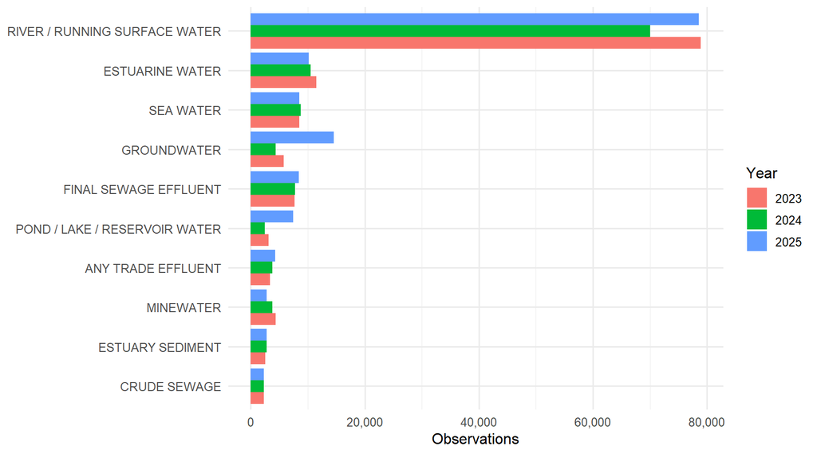

Figure 1: Sample Material Type and Coverage

```r
# Count the observations recorded for each sample material type
# in each year. This helps us understand the composition of the
# combined dataset
water_all |>
  count(year, sampleMaterialType) |>
  group_by(sampleMaterialType) |>

  # Retain material types with more than 3,000 observations
  # across all three years. This threshold keeps the plot readable
  # by focusing on the more frequently recorded sample types
  filter(sum(n) > 3000) |>
  ungroup() |>

  # Compare annual observation counts for each retained material
  # type to see how their representation varies between years.
  # Reorder the categories by their total counts for easier reading
  ggplot(
    aes(
      x = n,
      y = forcats::fct_reorder(sampleMaterialType, n, sum),
      fill = factor(year)
    )
  ) +
  geom_col(position = "dodge") +
  scale_x_continuous(labels = scales::comma) +
  labs(
    x = "Observations",
    y = NULL,
    fill = "Year"
  )
```

Only a total of 639 sampling sites were monitored consistently across the three years (2023–2025), allowing comparisons of water quality at the same locations over time. Figure 2 shows the geographical distribution of these sampling sites across the study region.

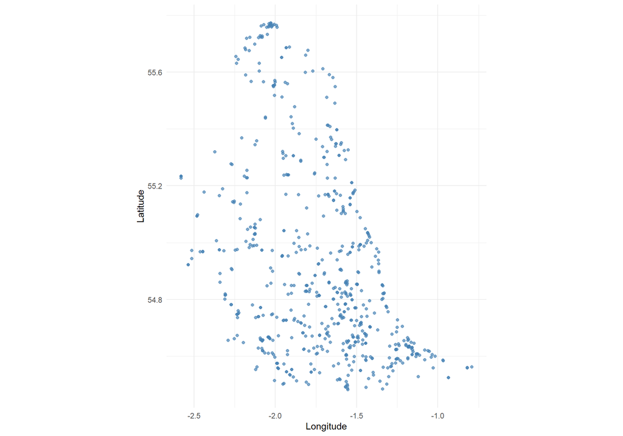

Figure 2: Geographical distribution of sampling sites monitored consistently across 2023–2025.

```r
# Extract the locations of sites identified as having records
# in all three study years. We use their coordinates to visualise
# where the shared sites are distributed across the study region
site_locations <- water_all |>
  filter(samplingPoint.notation %in% shared_sites) |>
  filter(
    !is.na(samplingPoint.longitude),
    !is.na(samplingPoint.latitude)
  ) |>

  # Keep each site-coordinate combination only once so that
  # repeated measurements do not create duplicate map points
  distinct(
    samplingPoint.notation,
    samplingPoint.longitude,
    samplingPoint.latitude
  )

# Map the sampling sites to show their geographical distribution.
# This helps us assess the spatial coverage of the sites included
# in the analysis, rather than relying on counts alone
ggplot(
  site_locations,
  aes(
    x = samplingPoint.longitude,
    y = samplingPoint.latitude
  )
) +
  geom_point(
    colour = "steelblue",
    alpha = 0.7,
    size = 1.5
  ) +

  # Use a map coordinate system to display the locations
  coord_quickmap() +
  labs(
    x = "Longitude",
    y = "Latitude"
  ) +
  theme_minimal()
```

### 2.3.2 Determinands, Measurement Units and Observation Frequencies

The datasets contain a range of water-quality determinands and measurement units. Table 1 presents the 15 most frequently recorded determinand and unit combinations, ranked by the number of observations.

```r
# Count the observations for each determinand and measurement unit,
# then rank them from most to least frequently recorded. This helps
# us understand which water quality measurements dominate the
# dataset before selecting indicators for the main analysis
water_all |>
  count(`determinand.prefLabel`, unit, sort = TRUE) |>
  slice_head(n = 15) |>

  # Format the results as a readable table, adding commas to large
  # observation counts so differences in recording frequency are
  # easier to compare
  kable(
    col.names = c("Determinand", "Unit", "Observations"),
    format.args = list(big.mark = ","),
  )
```

Table 1: Top 15 Determinands and Units by Number of Observations

| Determinand | Unit | Observations |
| --- | --- | --- |
| Temperature of Water | CELSIUS | 14,730 |
| BOD : 5 Day ATU | MILLIGRAM PER LITRE | 14,069 |
| Ammoniacal Nitrogen as N | MILLIGRAM PER LITRE | 13,552 |
| pH | PH UNITS | 11,869 |
| Solids, Suspended at 105 C | MILLIGRAM PER LITRE | 11,656 |
| Oxygen, Dissolved, % Saturation | PERCENTAGE | 10,557 |
| Nitrogen, Total Oxidised as N | MILLIGRAM PER LITRE | 9,937 |
| Nitrite as N | MILLIGRAM PER LITRE | 9,897 |
| Orthophosphate, reactive as P | MILLIGRAM PER LITRE | 9,741 |
| Nitrate as N | MILLIGRAM PER LITRE | 9,570 |
| Oxygen, Dissolved as O2 | MILLIGRAM PER LITRE | 9,194 |
| Conductivity at 25 C | MICROSIEMENS PER CENTIMETRE | 9,122 |
| Alkalinity to pH 4.5 as CaCO3 | MILLIGRAM PER LITRE | 7,846 |
| Ammonia un-ionised as N | MILLIGRAM PER LITRE | 7,085 |
| Phosphorus, Total as P | MILLIGRAM PER LITRE | 6,518 |

## 2.4 Data Quality Verification

### 2.4.1 Overview of Data Quality

This section checks for censored results, coded/text entries to identify potential issues before analysis.

```r
# Assess data quality separately for each year to identify
# whether censored and non-numeric results are common in the
# datasets and may affect the subsequent analysis
water_all |>
  group_by(year) |>

  # Calculate the proportion of results that may need special
  # treatment before statistical analysis
  summarise(

    # Identify results reported below the detection limit,
    # such as "<0.1". These are censored measurements because
    # the exact concentration is not reported
    pct_censored = mean(
      str_starts(result, "<"),
      na.rm = TRUE
    ),

    # Identify results recorded as coded or text entries rather
    # than numerical measurements. These may not be suitable
    # for calculations such as medians or statistical tests
    pct_non_numeric = mean(
      unit %in% c("Coded Result", "Text Result")
    )
  ) |>

  # Convert the proportions to percentages so that the extent
  # of these data-quality issues is easier to interpret
  mutate(
    across(
      starts_with("pct"),
      ~ percent_format(accuracy = 0.1)(.x)
    )
  ) |>

  # Present the annual data-quality checks in a readable table
  # so that differences between years can be compared
  kable(
    col.names = c(
      "Year",
      "Below detection limit (<)",
      "Coded/text results"
    ),
  )
```

Table 2: Data-quality indicators by year

| Year | Below detection limit (<) | Coded/text results |
| --- | --- | --- |
| 2023 | 22.7% | 1.0% |
| 2024 | 23.6% | 1.2% |
| 2025 | 29.7% | 1.9% |

Key observations:

- Censored results: Results column contains censored data (e.g. <0.1, below the lab detection limit)
- Coded/text results: Such entries may represent codes like “No flow / No sample” rather than numerical measurements.

### 2.4.2 Missing Values

This check counts missing values in each column to determine whether any data is incomplete.

```r
# Count missing values in every column of the combined dataset.
# This helps us identify variables with incomplete data before
# calculating summaries, producing plots, or conducting tests
water_all |>summarise(
    across(
      everything(),
      ~ sum(is.na(.x))
    )
  ) |>

  # Reshape the results into a two-column table so each variable
  # appears on its own row, making missing-value patterns easier
  # to inspect and compare across variables
  pivot_longer(
    cols = everything(),
    names_to = "Column",
    values_to = "Missing_Values"
  ) |>

  # Display the missing-value counts in a readable table
  kable(
    col.names = c("Column", "Number of Missing Values")
  )
```

Table 3: Missing values by column

| Column | Number of Missing Values |
| --- | --- |
| year | 0 |
| id | 0 |
| samplingPoint.notation | 0 |
| samplingPoint.prefLabel | 0 |
| samplingPoint.longitude | 0 |
| samplingPoint.latitude | 0 |
| samplingPoint.region | 0 |
| samplingPoint.area | 0 |
| samplingPoint.subArea | 0 |
| samplingPoint.samplingPointStatus | 0 |
| samplingPoint.samplingPointType | 0 |
| phenomenonTime | 0 |
| samplingPurpose | 0 |
| sampleMaterialType | 0 |
| determinand.notation | 0 |
| determinand.prefLabel | 0 |
| result | 0 |
| unit | 0 |

Key observation: There are no missing values in the dataset

### 2.4.3 Duplicate Records

This check identifies exact duplicate rows that could inflate observation counts and affect the analysis.

```r
# Check for exact duplicate rows in the combined dataset.
# Duplicate records could cause some measurements to be counted
# more than once, potentially affecting annual summaries and
# statistical comparisons
duplicate_count <- sum(duplicated(water_all))

# Display the duplicate count in a table to aid further assessment
tibble(
  Check = "Exact duplicate rows",
  Number_of_Duplicates = duplicate_count
) |>
  kable()
```

Table 4: Duplicate row check

| Check | Number_of_Duplicates |
| --- | --- |
| Exact duplicate rows | 0 |

Key observation: There are no duplicate rows in the dataset

# 3 Data Processing

## 3.1 Data Cleaning

### 3.1.1 Rename Columns

The original column names were renamed to shorter, descriptive, and consistent names to improve code readability and simplify subsequent data processing and analysis.

```r
# Rename selected columns to shorter, more consistent names.
# The original dataset uses long names with mixed naming styles,
# so standardising them makes the code easier to read and reduces
# the need to repeatedly reference lengthy column names
water_quality <- water_all |>
  rename(
    sampling_site_code = `samplingPoint.notation`,
    sampling_site_name = `samplingPoint.prefLabel`,
    longitude = `samplingPoint.longitude`,
    latitude = `samplingPoint.latitude`,
    region = `samplingPoint.region`,
    subarea = `samplingPoint.subArea`,
    sampling_site_type = `samplingPoint.samplingPointType`,
    sample_material_type = sampleMaterialType,
    sampling_purpose = samplingPurpose,
    determinand = `determinand.prefLabel`
  )


# Create a reference table linking each original column name
# to its new name. This documents the changes and helps readers
# understand the variables used throughout the remaining analysis
column_names <- tibble(
  Original_Name = c(
    "samplingPoint.notation",
    "samplingPoint.prefLabel",
    "samplingPoint.longitude",
    "samplingPoint.latitude",
    "samplingPoint.region",
    "samplingPoint.subArea",
    "samplingPoint.samplingPointType",
    "sampleMaterialType",
    "samplingPurpose",
    "determinand.prefLabel"
  ),
  New_Name = c(
    "sampling_site_code",
    "sampling_site_name",
    "longitude",
    "latitude",
    "region",
    "subarea",
    "sampling_site_type",
    "sample_material_type",
    "sampling_purpose",
    "determinand"
  )
)

# Display the original and new names side by side so readers
# can see how the dataset's column names were standardised
knitr::kable(
  column_names,
  col.names = c("Original Column Name", "New Column Name")
)
```

Table 5: Original and Renamed Dataset Columns

| Original Column Name | New Column Name |
| --- | --- |
| samplingPoint.notation | sampling_site_code |
| samplingPoint.prefLabel | sampling_site_name |
| samplingPoint.longitude | longitude |
| samplingPoint.latitude | latitude |
| samplingPoint.region | region |
| samplingPoint.subArea | subarea |
| samplingPoint.samplingPointType | sampling_site_type |
| sampleMaterialType | sample_material_type |
| samplingPurpose | sampling_purpose |
| determinand.prefLabel | determinand |

### 3.1.2 Remove Coded/Text Results

Text-based results e.g No flow or No sample, were removed to retain observations with usable measurement data for subsequent analysis.

```r
# Remove records labelled as coded or text results so that
# the working dataset focuses on numerical measurements
# suitable for the planned statistical summaries and tests
water_quality <- water_quality |>
    filter(!unit %in% c("Coded Result", "Text Result"))
```

After removing coded and text-based results, 384892 observations remained for further analysis.

### 3.1.3 Convert Results to Numeric Values

Results below the detection limit were assigned half their reported detection limit by multiplying the extracted numerical values by 0.5, providing an estimated value for analysis.

```r
# Convert water quality results into numeric values so they can
# be used in statistical summaries, visualisations, and tests.
# We also flag results below the detection limit because their
# exact concentrations are unknown and require special handling
water_quality <- water_quality |>
  mutate(

    # Identify results reported below the detection limit,
    # such as "<0.1", so they can be treated separately
    below_detection_limit = str_starts(result, "<"),

    # Extract the numeric part of each result for analysis
    numeric_result = parse_number(result),

    # Estimate censored values using the chosen fraction of the
    # detection-limit value, rather than treating them as exact
    numeric_result = if_else(
      below_detection_limit,
      numeric_result * CENSOR_FACTOR,
      numeric_result
    )
  )
# Identify non-missing results that could not be converted into
# numbers. Reviewing these entries helps reveal unexpected data
# formats that may need attention before the analysis proceeds
water_quality |>
  filter(is.na(numeric_result) & !is.na(result)) |>
  count(result, sort = TRUE) |>
  head(10)
```

```
# A tibble: 8 × 2
  result                               n
  <chr>                            <int>
1 No material present               5652
2 Not found                         2987
3 Trace present - 1 or 2 items      2327
4 Absent                             874
5 Some at intervals - 3 to 6 items   628
6 Present                            175
7 Done                                72
8 Not found in test                   19
```

### 3.1.4 Remove Rows with Missing Numeric Results

Rows with missing numeric water quality measurements were removed to retain usable observations for subsequent analysis.

```r
# Remove records without usable numeric measurements so that
# subsequent summaries and statistical analyses can work with
# valid numerical results
water_quality <- water_quality |>
  filter(!is.na(numeric_result))

# Report the number of rows remaining after cleaning and compare
# it with the original combined dataset to show the extent of
# records retained at this stage of data preparation
cat(
  "Rows after cleaning:",
  scales::comma(nrow(water_quality)),
  "of",
  scales::comma(nrow(water_all))
)
```

```
Rows after cleaning: 372,158 of 390,272
```

### 3.1.5 Parse Timestamps and Derive Month

Sampling timestamps were converted into a date-time format, and the corresponding month were derived to support the analysis of temporal variations in water quality.

```r
# Convert sampling timestamps into date-time values and extract
# the month of each observation. This prepares the data for
# monthly analysis
water_quality <- water_quality |>

  # Convert the original sampling timestamp into a date-time
  # format so its date components can be analysed
  mutate(
    sampling_datetime = ymd_hms(phenomenonTime),

    # Extract the month as a labelled value (Jan, Feb, etc.)
    # to support comparisons of water quality across the year
    sampling_month = month(sampling_datetime, label = TRUE)
  )
```

### 3.1.6 Extract Sample IDs

Sample identifiers were extracted from the original ID column to help link different determinand measurements originating from the same water sample.

```r
# Extract the numeric sample identifier from the original ID field.
# This creates a simpler sample ID that can help identify and
# match measurements belonging to the same sample in later analyses
water_quality <- water_quality |>
  mutate(
    sample_id = str_extract(id, "(?<=sample/)\\d+")
  )
```

## 3.2 Prepare the River Water Quality Analysis Subset

The cleaned dataset was filtered to include river water samples, the seven selected water quality indicators, and sampling sites monitored across all three years (2023–2025). Table 6 outlines observations for each indicator were summarized by year to assess data coverage.

```r
# Define the seven water quality indicators selected to answer
# the research question. Focusing on these indicators keeps the
# analysis centred on nutrients, oxygen conditions, BOD,
# temperature, and pH
core_water_quality_indicators <- c(
  "Nitrate as N",
  "Orthophosphate, reactive as P",
  "Ammoniacal Nitrogen as N",
  "Oxygen, Dissolved, % Saturation",
  "BOD : 5 Day ATU",
  "Temperature of Water",
  "pH"
)

# Create the analysis dataset by retaining river-water samples
# for the seven selected indicators at sites with records in all
# three study years. This supports comparisons across 2023–2025
river_water_quality <- water_quality |>
  filter(
    sample_material_type == "RIVER / RUNNING SURFACE WATER",
    determinand %in% core_water_quality_indicators,
    sampling_site_code %in% shared_sites
  ) |>
  mutate(
    determinand = factor(
      determinand,
      levels = core_water_quality_indicators
    )
  )

# Set a consistent indicator order so the indicators appear
# in the same sequence in subsequent tables and visualisations.
river_water_quality |>
  count(determinand, year) |>
  pivot_wider(
    names_from = year,
    values_from = n,
    values_fill = 0
  ) |>

  # Display the annual observation counts in a readable table.
  knitr::kable()
```

Table 6: Observations in the River Water Quality Analysis Subset

| determinand | 2023 | 2024 | 2025 |
| --- | --- | --- | --- |
| Nitrate as N | 2028 | 2250 | 2156 |
| Orthophosphate, reactive as P | 2077 | 2273 | 2198 |
| Ammoniacal Nitrogen as N | 2088 | 2288 | 2222 |
| Oxygen, Dissolved, % Saturation | 1835 | 1910 | 2043 |
| BOD : 5 Day ATU | 137 | 1132 | 863 |
| Temperature of Water | 2575 | 2643 | 2467 |
| pH | 1980 | 1985 | 2115 |

These seven indicators were selected to assess different aspects of river water quality. Nitrate, orthophosphate and ammoniacal nitrogen indicate nutrient levels and potential pollution. Dissolved oxygen and biochemical oxygen demand (BOD) help assess oxygen conditions and organic pollution, while pH and temperature provide information on the water’s chemical and thermal conditions. Together, these indicators provide a basis for examining changes in river water quality between 2023 and 2025 (UKTAG, 2008a; UKTAG, 2008b; Council of the European Communities, 1991)

# 4 Modelling and Analysis

## 4.1 Year-on-Year Summary

The median and interquartile range (IQR) of each water quality indicator were calculated for 2023, 2024, and 2025 to summarize annual patterns and compare changes in recorded water quality measurements over time. Table 7 presents the annual summary statistics, while Figure 3 shows how the measurements were distributed across the three years

```r
# Calculate annual summary statistics for each indicator and unit.
# The median describes the typical measurement, while the first
# and third quartiles show the middle 50% of observed values.
# These statistics help us compare water quality across the years
# without relying solely on averages that can be affected by extremes
summary_table <- river_water_quality |>
  group_by(determinand, unit, year) |>
  summarise(
    median = median(numeric_result, na.rm = TRUE),
    first_quartile = quantile(numeric_result, 0.25, na.rm = TRUE),
    third_quartile = quantile(numeric_result, 0.75, na.rm = TRUE),
    .groups = "drop"
  )

# Combine the median and quartiles into one readable summary.
# Using a consistent format makes annual values easier to compare
# across indicators while retaining information about variability
summary_table |>
  mutate(
    summary = sprintf(
      "%.3g (%.3g–%.3g)",
      median,
      first_quartile,
      third_quartile
    )
  ) |>
  select(determinand, unit, year, summary) |>

  # Place each year in a separate column so changes over time
  # can be compared directly for each indicator and measurement unit
  pivot_wider(
    names_from = year,
    values_from = summary
  ) |>

  # Present the annual summaries with column headings
  # for interpretation in the report
  knitr::kable(
    col.names = c("Determinand", "Unit", "2023", "2024", "2025"),
  )
```

Table 7: Annual Summary of Water Quality Measurements

| Determinand | Unit | 2023 | 2024 | 2025 |
| --- | --- | --- | --- | --- |
| Nitrate as N | MILLIGRAM PER LITRE | 1.49 (0.506–2.9) | 1.69 (0.368–3.17) | 0.843 (0.239–2.3) |
| Orthophosphate, reactive as P | MILLIGRAM PER LITRE | 0.021 (0.0051–0.074) | 0.02 (0.005–0.064) | 0.014 (0.005–0.04) |
| Ammoniacal Nitrogen as N | MILLIGRAM PER LITRE | 0.015 (0.015–0.042) | 0.015 (0.015–0.045) | 0.015 (0.015–0.0377) |
| Oxygen, Dissolved, % Saturation | PERCENTAGE | 98.8 (93.5–102) | 99.1 (94.9–102) | 99.4 (95.5–102) |
| BOD : 5 Day ATU | MILLIGRAM PER LITRE | 1.5 (1.1–2.1) | 1.5 (1.2–1.9) | 1.5 (1.2–1.8) |
| Temperature of Water | CELSIUS | 10 (6.3–13.7) | 8.9 (5.9–12.7) | 9.3 (6.1–13) |
| pH | PH UNITS | 7.97 (7.73–8.2) | 7.98 (7.73–8.19) | 8.03 (7.78–8.24) |

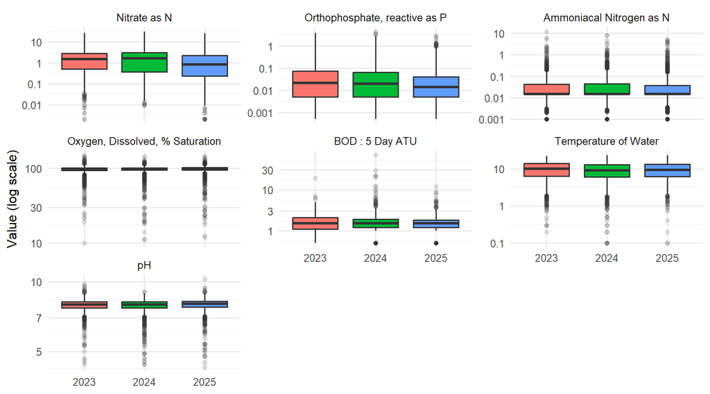

Figure 3: Distribution of Water Quality Measurements Across Years

```r
# Compare water quality measurements across the three study years.
# We exclude zero and negative values because they cannot be shown
# on a logarithmic axis
river_water_quality |>
  filter(numeric_result > 0) |>
  ggplot(aes(factor(year), numeric_result, fill = factor(year))) +

  # Use boxplots to compare annual medians, variability, and
  # potential outliers for each water quality indicator
  geom_boxplot(outlier.alpha = 0.15, show.legend = FALSE) +

  # Give each indicator its own panel and vertical scale because
  # the indicators have different measurement ranges and units
  facet_wrap(~determinand, scales = "free_y", ncol = 3) +

  # Apply a logarithmic scale to make differences across a wide
  # range of positive measurements easier to visualise
  scale_y_log10(
    labels = scales::label_number(drop0trailing = TRUE)
  ) +

  # Label the axes while keeping the year labels clear and simple.
  labs(
    x = NULL,
    y = "Value (log scale)"
  )
```

The annual summaries show that median nitrate and orthophosphate concentrations decreased between 2023 and 2025. Dissolved oxygen saturation increased slightly, while the median values of ammoniacal nitrogen and five-day biochemical oxygen demand remained stable. These changes describe the observed annual patterns

## 4.2 Are the Differences Between Years Significant?

The Kruskal–Wallis test was used to assess whether water quality measurements differed across 2023, 2024 and 2025 (Kruskal and Wallis, 1952). The Benjamini–Hochberg method was applied to adjust p-values for multiple testing (Benjamini and Hochberg, 1995), while effect sizes were calculated to assess the magnitude of the differences. Table 8 presents the test results for each indicator. For indicators with significant differences, Dunn’s post-hoc test was used to identify which pairs of years differed (Dunn, 1964; Table 9).

```r
# Test whether the distributions of each water quality indicator
# differ across 2023, 2024 and 2025. The Kruskal–Wallis test
# provides a non-parametric comparison across the three years
kruskal_results <- river_water_quality |>
  mutate(year = factor(year)) |>
  group_by(determinand) |>
  kruskal_test(numeric_result ~ year) |>

  # Apply the Benjamini–Hochberg adjustment to account for
  # multiple tests and reduce the risk of false-positive findings
  adjust_pvalue(method = "BH")

# Calculate an effect size for each indicator to assess how large
# the differences between years are, alongside statistical
# significance. This helps distinguish small differences from
# potentially more substantial changes in water quality
effect_results <- river_water_quality |>
  mutate(year = factor(year)) |>
  group_by(determinand) |>
  kruskal_effsize(numeric_result ~ year)

# Combine the test results with their corresponding effect sizes
# so statistical significance and the magnitude of differences
# can be examined together for each indicator
kruskal_results |>
  left_join(
    select(effect_results, determinand, effsize, magnitude),
    by = "determinand"
  ) |>

  # Keep the key statistics needed to interpret the results
  select(determinand, n, statistic, p.adj, effsize, magnitude) |>

  # Format adjusted p-values for readability in the report
  mutate(
    p.adj = format.pval(p.adj, digits = 3, eps = 1e-4)
  ) |>

  # Present the statistical results and effect sizes in a
  # consistent table for comparison across indicators
  knitr::kable(
    digits = 3,
    col.names = c(
      "Determinand",
      "Sample Size",
      "H Statistic",
      "Adjusted p-value",
      "Effect Size",
      "Effect Magnitude"
    ),
  )
```

Table 8: Kruskal–Wallis Test Results by Water Quality Indicator

| Determinand | Sample Size | H Statistic | Adjusted p-value | Effect Size | Effect Magnitude |
| --- | --- | --- | --- | --- | --- |
| Nitrate as N | 6434 | 112.622 | <1e-04 | 0.017 | small |
| Orthophosphate, reactive as P | 6548 | 91.438 | <1e-04 | 0.014 | small |
| Ammoniacal Nitrogen as N | 6598 | 38.580 | <1e-04 | 0.006 | small |
| Oxygen, Dissolved, % Saturation | 5788 | 22.821 | <1e-04 | 0.004 | small |
| BOD : 5 Day ATU | 2132 | 0.420 | 0.81 | 0.000 | small |
| Temperature of Water | 7685 | 35.522 | <1e-04 | 0.004 | small |
| pH | 6080 | 29.737 | <1e-04 | 0.005 | small |

Pairwise follow-up (Dunn’s test) for indicators with a significant result:

```r
# Identify indicators that showed significant differences between years
# in the overall Kruskal–Wallis tests.
significant_determinand <- kruskal_results |>
  filter(p.adj < 0.05) |>
  pull(determinand)

# Compare the years in pairs for each indicator with a significant
# overall result, using adjusted p-values to account for multiple tests
river_water_quality |>
  filter(determinand %in% significant_determinand) |>
  mutate(year = factor(year)) |>
  group_by(determinand) |>
  dunn_test(
    numeric_result ~ year,
    p.adjust.method = "BH"
  ) |>

  # Retain the results needed to identify the year pairs that differ
  select(
    determinand,
    group1,
    group2,
    statistic,
    p.adj,
    p.adj.signif
  ) |>

  # Present the pairwise comparisons in a readable table
  knitr::kable(
    digits = 3,
    col.names = c(
      "Determinand",
      "Year 1",
      "Year 2",
      "Test Statistic",
      "Adjusted p-value",
      "Significance"
    ),
  )
```

Table 9: Dunn’s Post-hoc Test Results Between Years

| Determinand | Year 1 | Year 2 | Test Statistic | Adjusted p-value | Significance |
| --- | --- | --- | --- | --- | --- |
| Nitrate as N | 2023 | 2024 | 0.105 | 0.916 | ns |
| Nitrate as N | 2023 | 2025 | -9.006 | 0.000 | **** |
| Nitrate as N | 2024 | 2025 | -9.351 | 0.000 | **** |
| Orthophosphate, reactive as P | 2023 | 2024 | -0.728 | 0.467 | ns |
| Orthophosphate, reactive as P | 2023 | 2025 | -8.531 | 0.000 | **** |
| Orthophosphate, reactive as P | 2024 | 2025 | -7.988 | 0.000 | **** |
| Ammoniacal Nitrogen as N | 2023 | 2024 | 1.894 | 0.058 | ns |
| Ammoniacal Nitrogen as N | 2023 | 2025 | -4.072 | 0.000 | **** |
| Ammoniacal Nitrogen as N | 2024 | 2025 | -6.092 | 0.000 | **** |
| Oxygen, Dissolved, % Saturation | 2023 | 2024 | 1.305 | 0.192 | ns |
| Oxygen, Dissolved, % Saturation | 2023 | 2025 | 4.606 | 0.000 | **** |
| Oxygen, Dissolved, % Saturation | 2024 | 2025 | 3.314 | 0.001 | ** |
| Temperature of Water | 2023 | 2024 | -5.946 | 0.000 | **** |
| Temperature of Water | 2023 | 2025 | -3.316 | 0.001 | ** |
| Temperature of Water | 2024 | 2025 | 2.544 | 0.011 | * |
| pH | 2023 | 2024 | -0.579 | 0.562 | ns |
| pH | 2023 | 2025 | 4.374 | 0.000 | **** |
| pH | 2024 | 2025 | 4.966 | 0.000 | **** |

The Kruskal–Wallis test showed significant differences across years for six of the seven indicators (adjusted p < 0.05). Nitrate and orthophosphate had the largest effect sizes (0.017 and 0.014, respectively), although both were small. BOD showed no significant difference (p = 0.81). Dunn’s post-hoc tests showed that most significant differences involved 2025, while water temperature differed across all three year-to-year comparisons. Overall, the findings indicate temporal variation, but the small effect sizes suggest that the magnitude of these differences was limited.

## 4.3 Seasonal Patterns in Water Quality

Monthly median values were calculated for water temperature and dissolved oxygen saturation to examine seasonal patterns across 2023, 2024, and 2025.

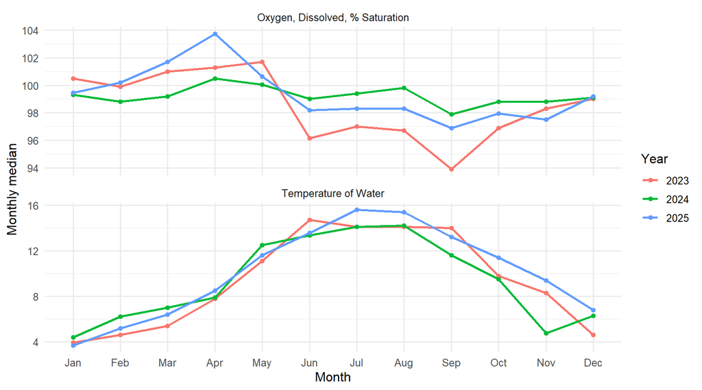

Figure 4: Monthly Patterns in Water Temperature and Dissolved Oxygen

```r
# Select water temperature and dissolved oxygen saturation to
# investigate how these indicators vary throughout the year
# and whether their monthly patterns differ across study years
river_water_quality |>
  filter(
    determinand %in% c(
      "Temperature of Water",
      "Oxygen, Dissolved, % Saturation"
    )
  ) |>

  # Calculate the median for each month, year and indicator.
  # Monthly medians summarise typical conditions while reducing
  # the influence of unusually high or low individual readings
  group_by(determinand, year, sampling_month) |>
  summarise(
    median = median(numeric_result, na.rm = TRUE),
    .groups = "drop"
  ) |>

  # Plot the monthly medians as lines so seasonal patterns and
  # differences between years can be compared visually
  ggplot(
    aes(
      x = sampling_month,
      y = median,
      colour = factor(year),
      group = year
    )
  ) +
  geom_line(linewidth = 1) +
  geom_point() +

  # Separate the indicators into panels because they use different
  # measurement scales and should not share the same y-axis
  facet_wrap(~determinand, scales = "free_y", ncol = 1) +

  # Label the axes and year colours to make the comparisons clear
  labs(
    x = "Month",
    y = "Monthly median",
    colour = "Year",
  )
```

Seasonal variation occurs in water temperature, with monthly medians generally increasing towards summer and decreasing towards winter. Dissolved oxygen saturation varies across months and years, with more noticeable declines in some months of 2023 and 2025.

## 4.4 Catchment (Sub-area) Comparison

Nutrient concentrations were compared across sampling sub-areas to identify geographical differences in river water quality. Median concentrations of ammoniacal nitrogen, orthophosphate and nitrate were calculated for each sub-area and year. Figure 5 compares the median concentrations across years, while Table 10 summarises the absolute and percentage changes between 2023 and 2025.

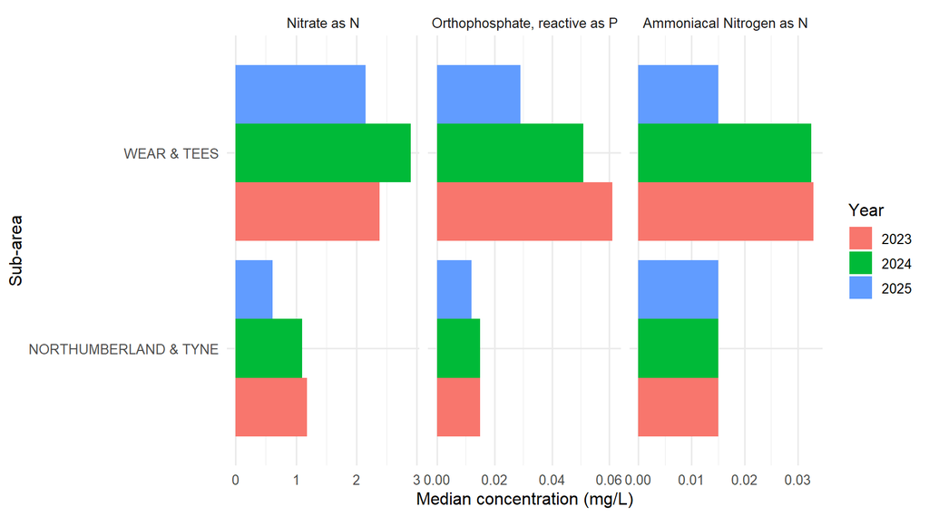

Figure 5: Median Nutrient Concentrations by Sub-area and Year

```r
# Select the three nutrient indicators to compare their typical
# concentrations across sub-areas and study years
river_water_quality |>
  filter(
    determinand %in% c(
      "Ammoniacal Nitrogen as N",
      "Orthophosphate, reactive as P",
      "Nitrate as N"
    )
  ) |>

  # Retain sub-areas with at least five distinct sampling sites
  # to provide a minimum level of geographical coverage
  group_by(subarea) |>
  filter(n_distinct(sampling_site_code) >= 5) |>

  # Calculate the median concentration for each indicator,
  # sub-area and year. These summaries make it easier to compare
  # typical nutrient levels without relying on individual readings
  group_by(determinand, subarea, year) |>
  summarise(
    median = median(numeric_result, na.rm = TRUE),
    .groups = "drop"
  ) |>

  # Plot the annual medians side by side for each sub-area.
  # Reordering the sub-areas by their median values improves
  # readability, while separate panels allow each nutrient
  # to be examined independently
  ggplot(
    aes(
      x = median,
      y = forcats::fct_reorder(subarea, median),
      fill = factor(year)
    )
  ) +
  geom_col(position = "dodge") +

  # Give each nutrient its own horizontal scale because their
  # concentration ranges may differ
  facet_wrap(~determinand, scales = "free_x") +
  labs(
    x = "Median concentration (mg/L)",
    y = "Sub-area",
    fill = "Year"
  )
```

```r
# Select the three nutrient indicators and the first and final
# study years to assess how their median concentrations changed
# between 2023 and 2025 across the study sub-areas
catchment_changes <- river_water_quality |>
  filter(
    determinand %in% c(
      "Nitrate as N",
      "Orthophosphate, reactive as P",
      "Ammoniacal Nitrogen as N"
    ),
    year %in% c(2023, 2025)
  ) |>

  # Retain sub-areas represented by at least five distinct
  # sampling sites, helping avoid comparisons based on very
  # limited geographical coverage
  group_by(subarea) |>
  filter(n_distinct(sampling_site_code) >= 5) |>
  ungroup() |>

  # Calculate the median concentration for each nutrient
  # in each sub-area and year, providing a summary for comparison
  group_by(subarea, determinand, year) |>
  summarise(
    median_concentration = median(
      numeric_result,
      na.rm = TRUE
    ),
    .groups = "drop"
  ) |>

  # Place the 2023 and 2025 medians in separate columns so
  # changes over the study period can be calculated directly
  pivot_wider(
    names_from = year,
    values_from = median_concentration,
    names_prefix = "year_"
  ) |>

  # Calculate the absolute and percentage changes between
  # 2023 and 2025. Percentage change is left undefined when
  # the 2023 median is missing or zero
  mutate(
    absolute_change = year_2025 - year_2023,
    percentage_change = if_else(
      !is.na(year_2023) & year_2023 != 0,
      (absolute_change / year_2023) * 100,
      NA_real_
    )
  ) |>

  # Arrange the results by indicator and sub-area to make
  # geographical comparisons easier to follow
  arrange(determinand, subarea)

catchment_changes |>

  # Round numerical values to three decimal places and display
  # the results in a table for interpretation
  mutate(
    across(
      where(is.numeric),
      ~ round(.x, 3)
    )
  ) |>
  kable(
    col.names = c(
      "Sub-area",
      "Indicator",
      "2023 Median",
      "2025 Median",
      "Absolute Change",
      "Change (%)"
    )
  )
```

Table 10: Changes in Median Nutrient Concentrations by Sub-area, 2023–2025

| Sub-area | Indicator | 2023 Median | 2025 Median | Absolute Change | Change (%) |
| --- | --- | --- | --- | --- | --- |
| NORTHUMBERLAND & TYNE | Nitrate as N | 1.180 | 0.616 | -0.564 | -47.797 |
| WEAR & TEES | Nitrate as N | 2.380 | 2.155 | -0.225 | -9.454 |
| NORTHUMBERLAND & TYNE | Orthophosphate, reactive as P | 0.015 | 0.012 | -0.003 | -20.000 |
| WEAR & TEES | Orthophosphate, reactive as P | 0.061 | 0.029 | -0.032 | -52.459 |
| NORTHUMBERLAND & TYNE | Ammoniacal Nitrogen as N | 0.015 | 0.015 | 0.000 | 0.000 |
| WEAR & TEES | Ammoniacal Nitrogen as N | 0.033 | 0.015 | -0.018 | -54.545 |

Median nutrient concentrations varied between the two sub-areas and across the three years. Wear & Tees generally recorded higher concentrations than Northumberland & Tyne for all three nutrient indicators.

## 4.5 Spatial View of Ammonia Levels

The median ammoniacal nitrogen concentration was calculated for each sampling site and year. The plot uses sampling coordinates to show the geographical distribution of ammonia levels and compare patterns across 2023, 2024, and 2025.

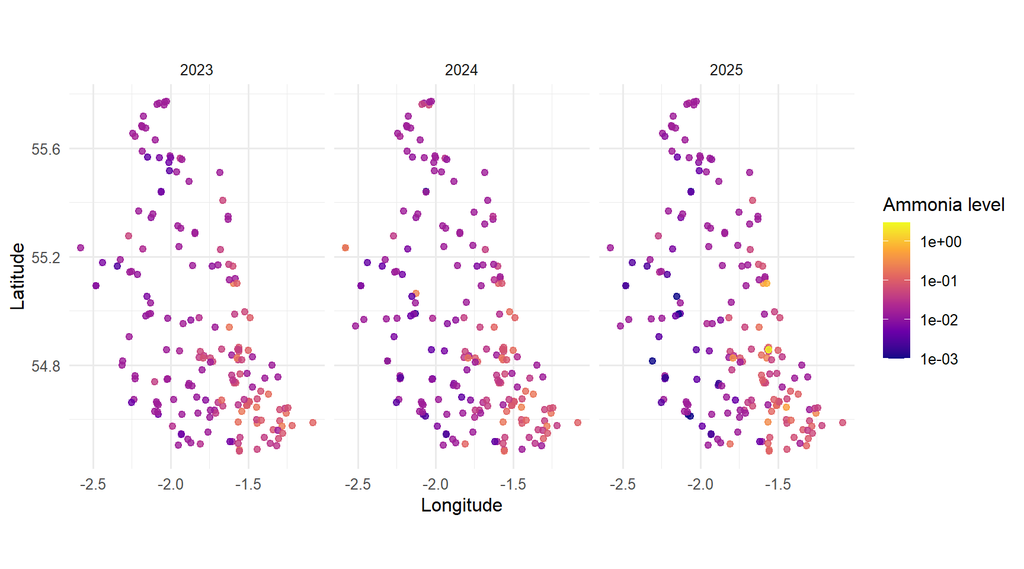

Figure 6: Spatial Distribution of Median Ammoniacal Nitrogen Levels by Sampling Site and Year

```r
# Calculate the median ammoniacal nitrogen concentration at each
# sampling site for each year. Using the median summarises the
# typical recorded level at each location while reducing the
# influence of unusually high or low individual measurements
site_medians <- river_water_quality |>
  filter(determinand == "Ammoniacal Nitrogen as N") |>
  group_by(sampling_site_code, year, longitude, latitude) |>
  summarise(
    median = median(numeric_result, na.rm = TRUE),
    .groups = "drop"
  )

# Map the site-level medians to examine how ammoniacal nitrogen
# concentrations vary geographically and between study years.
# Each point represents a sampling site, with its colour showing
ggplot(site_medians, aes(longitude, latitude, colour = median)) +
  geom_point(alpha = 0.8, size = 1.8) +

  # Apply a logarithmic colour scale to make differences across
  # a wide range of positive concentrations easier to distinguish
  scale_colour_viridis_c(trans = "log10", option = "plasma") +

  # Adjust the map's aspect ratio to make the spatial display
  # more geographically representative
  coord_quickmap() +

  # Display each year in a separate panel to support comparison
  # of the spatial patterns across 2023, 2024, and 2025
  facet_wrap(~year) +
  labs(
    x = "Longitude",
    y = "Latitude",
    colour = "Ammonia level"
  )
```

Higher concentrations appear concentrated in some sites, particularly in the south-eastern part of the mapped area, while lower levels occur at other locations. The overall spatial pattern appears broadly similar across the three years, although concentrations vary between sites. This highlights the importance of continued monitoring at locations with elevated levels

## 4.6 Relationships Between Indicators

Measurements from the same water sample were matched using sample_id to examine relationships between water quality indicators. Spearman correlation was used to assess the strength and direction of these relationships.

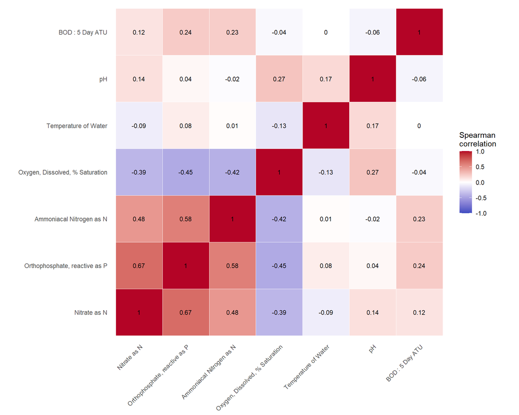

Figure 7: Spearman Correlation Matrix of Water Quality Indicators

```r
# Prepare the data for correlation analysis by retaining records
# with valid sample IDs and finite numeric results. We then
# summarise repeated measurements for each sample and indicator
# so that each sample contributes one value per indicator
correlation_wide <- river_water_quality |>
  filter(
    !is.na(sample_id),
    !is.na(numeric_result),
    is.finite(numeric_result)
  ) |>
  group_by(sample_id, determinand) |>
  summarise(
    numeric_result = mean(numeric_result),
    .groups = "drop"
  ) |>

  # Arrange the data so each indicator becomes a column.
  # This format allows us to calculate correlations between
  # the indicators using their measurements within samples
  pivot_wider(
    names_from = determinand,
    values_from = numeric_result
  )

# Calculate pairwise Spearman correlations between the numeric
# indicators. This method assesses whether indicators tend to
# increase or decrease together in a monotonic relationship.
# Pairwise complete observations allow each correlation to use
# samples with valid values for that particular pair of indicators
correlation_matrix <- correlation_wide |>
  select(-sample_id) |>
  select(where(is.numeric)) |>
  cor(
    method = "spearman",
    use = "pairwise.complete.obs"
  )

# Convert the correlation matrix into a long-format table so
# each indicator pair and its correlation coefficient can be
# plotted as an individual tile in the heatmap
correlation_data <- as.data.frame(as.table(correlation_matrix)) |>
  rename(
    Indicator1 = Var1,
    Indicator2 = Var2,
    Correlation = Freq
  ) |>
  filter(is.finite(Correlation))

# Visualise the correlation heatmap.
# The colours show negative and positive associations, while
# the labels provide the correlation coefficient for each pair
ggplot(
  correlation_data,
  aes(x = Indicator1, y = Indicator2, fill = Correlation)
) +
  geom_tile(color = "white") +
  geom_text(aes(label = round(Correlation, 2)), size = 3) +
  scale_fill_gradient2(
    low = "#3B4CC0",
    mid = "white",
    high = "#B40426",
    midpoint = 0,
    limits = c(-1, 1),
    name = "Spearman\ncorrelation"
  ) +

  # Keep the tiles square so the matrix is easier to read
  coord_fixed() +
  labs(
    x = NULL,
    y = NULL
  ) +
  theme_minimal() +
  theme(
    axis.text.x = element_text(angle = 45, hjust = 1),
    panel.grid = element_blank()
  )
```

Nutrient indicators tend to be positively related, while higher nutrient levels are associated with lower dissolved oxygen saturation. Most other relationships are weak. However, correlation does not imply causation.

# 5 Evaluation

## 5.1 Key Findings

The analysis identified the following key findings between 2023 and 2025:

- Nitrate: Median concentration decreased from 1.49 mg/L in 2023 to 0.843 mg/L in 2025.
- Orthophosphate: Median concentration decreased from 0.021 mg/L in 2023 to 0.014 mg/L in 2025.
- Ammoniacal nitrogen: Median concentration remained stable at 0.015 mg/L across all three years.
- Biochemical oxygen demand (BOD): Median concentration remained at 1.5 mg/L, with no statistically significant difference between years.
- Dissolved oxygen saturation: Median increased slightly from 98.8% in 2023 to 99.4% in 2025.
- pH: Median increased slightly from 7.97 to 8.03.
- Water temperature: Median decreased from 10°C in 2023 to 9.3°C in 2025, after reaching 8.9°C in 2024.
- Statistical significance: Six of the seven indicators showed statistically significant differences across years, but all effect sizes were small (Table 8).
- Geographical variation: Figure 5 shows that Wear & Tees generally recorded higher median nutrient concentrations than Northumberland & Tyne.

## 5.2 Did Water Quality in North England Improve or Decline?

Overall, water quality showed some signs of improvement, particularly the reductions in median nitrate and orthophosphate concentrations and the slight increase in dissolved oxygen saturation. However, the small effect sizes and stability of other indicators mean that the results do not demonstrate a clear, overall improvement across all aspects of water quality.

## 5.3 Which Catchments and Pollutants Drove the Change?

The comparison between 2023 and 2025 showed that Wear & Tees experienced the largest reductions in orthophosphate (52.5%) and ammoniacal nitrogen (54.5%). Nitrate decreased by 9.5% in Wear & Tees, compared with 47.8% in Northumberland & Tyne. Orthophosphate also decreased by 20.0% in Northumberland & Tyne, while ammoniacal nitrogen remained unchanged. Overall, Wear & Tees recorded the greatest reductions in two of the three nutrient indicators, while Northumberland & Tyne recorded the larger reduction in nitrate

## 5.5 Where I Would Iterate

If the analysis were to be repeated, I would use a statistical method that accounts for repeated measurements at the same sampling sites across years, such as a Friedman test or a mixed-effects model. I would also investigate how results below the detection limit affect the ammoniacal nitrogen findings, particularly the reported reduction in Wear & Tees. Finally, I would explore additional years of data to establish whether the observed changes represent longer-term patterns in river water quality.

# 6 Deployment

## 6.1 Tools and Technologies

The analysis was carried out using R and Quarto, and the final report was produced as an HTML document. The report brings together the tables, graphs and statistical results, making it easier to explore changes in river water quality between 2023 and 2025. The code is included in collapsible sections so readers can view it when needed.

## 6.2 Recommendations

The findings are intended for environmental researchers, water quality monitoring teams and other relevant stakeholders. The report communicates changes in nutrient concentrations, dissolved oxygen, temperature and other selected indicators to support the interpretation of water quality patterns across the study region.

Based on the findings, the following recommendations are proposed:

- Prioritise monitoring in Wear & Tees: The generally higher nutrient concentrations observed in this sub-area warrant further investigation to identify potential pollution sources and locations requiring closer monitoring.
- Continue monitoring nutrient levels: Nitrate and orthophosphate concentrations should be monitored over time to determine whether the observed reductions persist and to identify any subsequent deterioration.
- Improve the interpretation of ammoniacal nitrogen results: The treatment of measurements below detection limits should be considered when assessing changes in ammonia concentrations, as substituted values may affect the apparent trends.
- Investigate relationships between indicators: The observed associations between nutrient concentrations and dissolved oxygen should guide further investigation, without assuming that correlation establishes causation.
- Improve consistency in sampling: More consistent monitoring across sites and years would strengthen future comparisons and help distinguish genuine changes in water quality from differences in sampling coverage.

These recommendations provide a basis for further investigation and monitoring decisions. The findings should be interpreted alongside the study’s limitations, and additional evidence should be gathered before specific pollution sources or causes are established.

# 7 References

- Chapman, P., Clinton, J., Kerber, R., Khabaza, T., Reinartz, T., Shearer, C. and Wirth, R. (2000). *CRISP-DM 1.0: Step-by-step data mining guide*. SPSS Inc.
- Wickham, H., Çetinkaya-Rundel, M. and Grolemund, G. (2023). [*R for Data Science (2nd Edition)*](https://r4ds.hadley.nz/)
- UK Technical Advisory Group (UKTAG) (2008a). [*UKTAG Environmental Standards and Conditions (Phase 1) – 2008*](https://www.daera-ni.gov.uk/publications/uktag-environmental-standards-and-conditions-phase-1-2008).
- UK Technical Advisory Group (UKTAG) (2008b). [*UK Environmental Standards and Conditions (Phase 2) – 2008*](https://www.daera-ni.gov.uk/publications/uktag-environmental-standards-and-conditions-phase-2-2008).
- Kruskal, W.H. and Wallis, W.A. (1952). [*Use of Ranks in One-Criterion Variance Analysis*](https://doi.org/10.1080/01621459.1952.10483441)
- Benjamini, Y. and Hochberg, Y. (1995) ‘Controlling the false discovery rate: A practical and powerful approach to multiple testing’, *Journal of the Royal Statistical Society: Series B (Methodological)*, 57(1), pp. 289–300. https://doi.org/10.1111/j.2517-6161.1995.tb02031.x.
- Dunn, O. J. (1964) ‘Multiple comparisons using rank sums’, *Technometrics*, 6(3), pp. 241–252. https://doi.org/10.1080/00401706.1964.10490181.